# Process 2021 eDNA Data- Eulachon

Owen R. Liu

2023-10-16

# Purpose

# Import Data

First, we import “raw” forms of the data.

```r
# Pull in qPCR data, qPCR standards, sample id information
dat.all <- read_csv(here('data','qPCR','Hake eDNA 2021 qPCR results 10.13.2023.csv'))
dat.stand <- read_csv(here('Data','qPCR','Hake eDNA 2021 qPCR standards 10.13.2023.csv'))
dat.sample.id <- read_csv(here('Data','qPCR','Hake eDNA 2021 qPCR sample details 10.16.2023.csv'),skip=2)
dat.station.id <- read_csv(here('Data','CTD meta 2021.csv'))
```

# Process CTD

First, process the location and sample identifier information from CTD casts.

```r
# Look at the data
glimpse(dat.station.id)
```

```
## Rows: 215
## Columns: 6
## $ `Station ID` <chr> "Precalibration", "Precalibration", "Postcalibration", "X1_150", "X1_300", "X1_500", "X1_500.…
## $ `File name`  <chr> "000.hdr", "001.hdr", "002.hdr", "003.hdr", "004.hdr", "005.hdr", "006.hdr", "007.hdr", "008.…
## $ UTCDate      <date> 2021-06-30, 2021-06-30, 2021-06-30, 2021-07-02, 2021-07-02, 2021-07-02, 2021-07-02, 2021-07-…
## $ UTCTime      <time> 16:19:35, 17:11:53, 22:02:40, 06:48:06, 07:38:56, 08:39:04, 10:00:26, 05:34:55, 06:53:00, 07…
## $ Latitude     <dbl> 36.63733, 36.63733, 36.63750, 34.44383, 34.44583, 34.44517, 34.44783, 34.77833, 34.77800, 34.…
## $ Longitude    <dbl> -121.8855, -121.8855, -121.8855, -120.6200, -120.6710, -120.7378, -120.8265, -120.6950, -120.…
```

```r
dat.station.id <- dat.station.id %>%
  rename(station_id=`Station ID`,filename=`File name`,date=UTCDate, time=UTCTime,lat=Latitude,lon=Longitude) %>%
  mutate(year=year(date),month=month(date),day=day(date))

glimpse(dat.station.id)
```

```
## Rows: 215
## Columns: 9
## $ station_id <chr> "Precalibration", "Precalibration", "Postcalibration", "X1_150", "X1_300", "X1_500", "X1_500.1"…
## $ filename   <chr> "000.hdr", "001.hdr", "002.hdr", "003.hdr", "004.hdr", "005.hdr", "006.hdr", "007.hdr", "008.hd…
## $ date       <date> 2021-06-30, 2021-06-30, 2021-06-30, 2021-07-02, 2021-07-02, 2021-07-02, 2021-07-02, 2021-07-03…
## $ time       <time> 16:19:35, 17:11:53, 22:02:40, 06:48:06, 07:38:56, 08:39:04, 10:00:26, 05:34:55, 06:53:00, 07:5…
## $ lat        <dbl> 36.63733, 36.63733, 36.63750, 34.44383, 34.44583, 34.44517, 34.44783, 34.77833, 34.77800, 34.77…
## $ lon        <dbl> -121.8855, -121.8855, -121.8855, -120.6200, -120.6710, -120.7378, -120.8265, -120.6950, -120.85…
## $ year       <dbl> 2021, 2021, 2021, 2021, 2021, 2021, 2021, 2021, 2021, 2021, 2021, 2021, 2021, 2021, 2021, 2021,…
## $ month      <dbl> 6, 6, 6, 7, 7, 7, 7, 7, 7, 7, 7, 7, 7, 7, 7, 7, 7, 7, 7, 7, 7, 7, 7, 7, 7, 7, 7, 7, 7, 7, 7, 7,…
## $ day        <int> 30, 30, 30, 2, 2, 2, 2, 3, 3, 3, 3, 4, 4, 4, 4, 4, 4, 5, 5, 5, 5, 5, 6, 6, 6, 6, 6, 8, 8, 8, 8,…
```

```r
# Duplicate station IDs
dat.station.id %>% count(station_id) %>%
  filter(n>1)

# two "real" stations (x51_500 and x57_50) seem to have multiple samples. Look at them
station.id.dupes <- dat.station.id %>%
  filter(station_id %in% c("x51_500","x57_50"))

# are these going to mess up our matching?
station.dupes.samps <- dat.sample.id %>% filter(`CTD cast`%in% c("x51_500","x57_50"))

# yes, so for now just filter so we keep just the first cast
dat.station.id <- dat.station.id %>%
  group_by(station_id) %>%
  slice(1) %>%
  ungroup()
# now, all station IDs in this table are unique (1 row per station_ID)
```

Add a transect identifier

```r
dat.station.id <- dat.station.id %>%
  mutate(transect=str_split_i(station_id,"_",1) %>% str_to_lower()) %>%
  mutate(transect=ifelse(grepl('^x',transect),str_replace(transect,"x",""),transect)) %>%
  mutate(transect=as.integer(transect))

## NAs introduced here- okay because some obs aren't associated with a transect(e.g., calibration controls)
station.NAs <- dat.station.id %>% filter(is.na(transect))
station.NAs
```

## MarMap Depth

Attach depth from NOAA bathymetry

```r
### Go get bathymetric data from NOAA to overlay on the transects.
limits.for.map <- dat.station.id %>%
  st_as_sf(coords=c('lon','lat'),crs=4326) %>%
  st_bbox()+c(-1,-1,1,1) #add an extra degree on each side for buffer


b = getNOAA.bathy(lon1 = limits.for.map["xmin"],
          lon2 = limits.for.map[ "xmax" ],
          lat1 = limits.for.map["ymin"],
          lat2 = limits.for.map["ymax"],
          resolution = 1,keep = TRUE)
```

```r
# We can pull depth from each sample point
stations.bathy <- get.depth(b,x=dat.station.id %>%
                              dplyr::select(lon,lat),locator=F) %>%
  rename(bathy.bottom.depth=depth) %>%
  distinct()

dat.station.id <- dat.station.id %>% left_join(stations.bathy,by=join_by(lat,lon))
```

Clean up columns of sample ID table

```r
dat.sample.id  <- dat.sample.id %>%
  dplyr::select(sample=`Tube #`,
                station=`CTD cast`,
                Niskin,
                depth,
                drop.sample,
                field.negative.type,
                volume = water.filtered.L)
```

# Projection Grid Info

Pull in and create spatial grid to project on.

## 5km Grid Depth

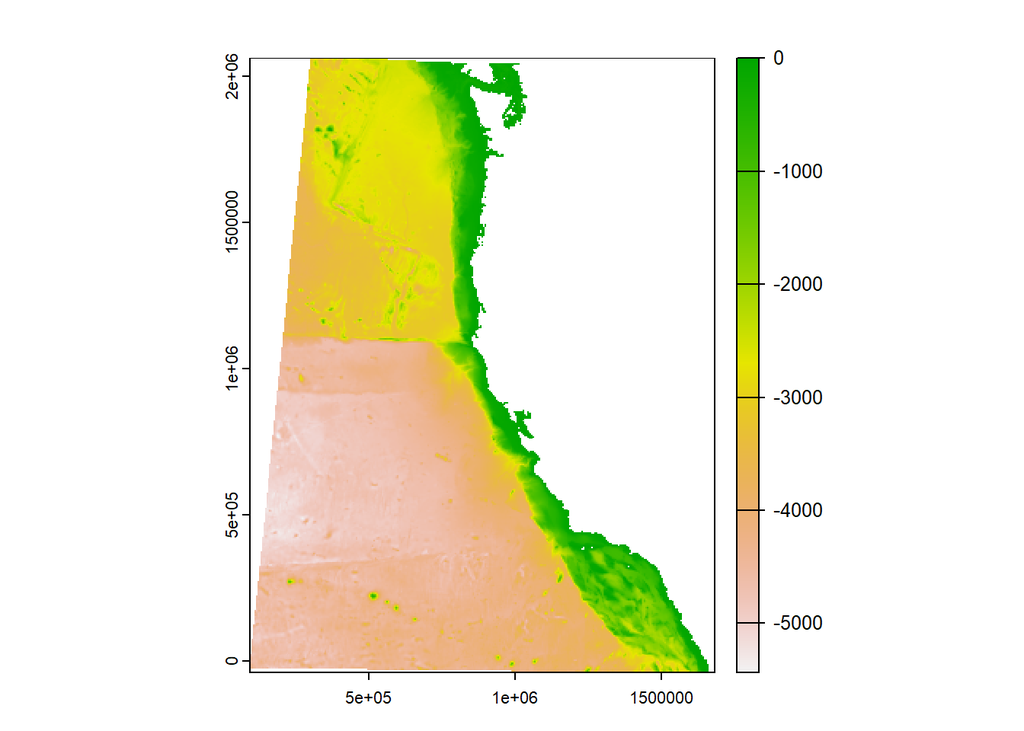

```r
# Blake's raster with just grid cell ID numbers
dat_raster=rast(here('Data','raster_grid_blake','fivekm_grid.tif'))

# Depth associated with grid cell IDs
raster_depth <- read_csv(here('Data','raster_grid_blake','weighted_mean_NGDC_depths_for_5km_gridcells.csv')) %>%
  rename(depth_m=WM_depth_m)

# join depths to cell numbers
cellnums <- tibble(rastID=as.numeric(values(dat_raster))) %>%
  mutate(rastcell=row_number()) %>%
  left_join(raster_depth,by=c("rastID"="Gridcell_ID"))

# make bathy raster
rast_depth <- setValues(dat_raster,cellnums$depth_m)
plot(rast_depth)
```

Convert spatial reference for station IDs to Blake’s custom projection

```r
dat.station.id.proj <- dat.station.id %>%
  # convert to sf object for quick and easy spatial transformation
  st_as_sf(coords=c('lon','lat'),crs=4326,remove=F) %>%
  # project to the same CRS as Blake's raster
  st_transform(crs(dat_raster)) %>%
  mutate(utm.lon.m=st_coordinates(.)[,1],
         utm.lat.m=st_coordinates(.)[,2]) %>%
  # convert back to a non-spatial df
  st_set_geometry(NULL)
glimpse(dat.station.id.proj)
```

```
## Rows: 209
## Columns: 13
## $ station_id         <chr> "048", "049", "050", "310_Sadie", "Calibration", "Leg3Calibration", "Postcalibration", …
## $ filename           <chr> "048.hdr", "049.hdr", "050.hdr", "047.hdr", "2021-09-23-Postcalibration.hdr", "2021-09-…
## $ date               <date> 2021-07-24, 2021-07-24, 2021-07-24, 2021-07-16, 2021-09-24, 2021-09-23, 2021-06-30, 20…
## $ time               <time> 09:50:38, 11:14:03, 12:24:55, 01:45:06, 00:39:18, 14:38:02, 22:02:40, 16:19:35, 01:23:…
## $ lat                <dbl> 38.11267, 38.11017, 38.11033, 43.68667, 47.62733, 47.62767, 36.63750, 36.63733, 36.9761…
## $ lon                <dbl> -123.3317, -123.5238, -123.6027, -124.8328, -122.4068, -122.4062, -121.8855, -121.8855,…
## $ year               <dbl> 2021, 2021, 2021, 2021, 2021, 2021, 2021, 2021, 2021, 2021, 2021, 2021, 2021, 2021, 202…
## $ month              <dbl> 7, 7, 7, 7, 9, 9, 6, 6, 6, 9, 7, 7, 7, 7, 7, 7, 7, 7, 7, 7, 7, 7, 7, 7, 7, 7, 7, 7, 7, …
## $ day                <int> 24, 24, 24, 16, 24, 23, 30, 30, 30, 17, 8, 8, 8, 8, 9, 9, 9, 9, 9, 10, 10, 10, 10, 11, …
## $ transect           <int> 48, 49, 50, 310, NA, NA, NA, NA, NA, NA, 13, 13, 13, 13, 15, 15, 15, 15, 15, 17, 17, 17…
## $ bathy.bottom.depth <dbl> -148.04114, -358.70438, -1575.98645, -704.73352, -103.48846, -36.07777, -57.70178, -57.…
## $ utm.lon.m          <dbl> 935685.0, 918791.1, 911861.8, 818757.1, 1014686.7, 1014737.3, 1063997.2, 1063997.3, 851…
## $ utm.lat.m          <dbl> 844005.1, 843858.4, 843939.1, 1462030.7, 1894107.1, 1894143.8, 680590.7, 680572.2, 7190…
```

## Distance Along Transect

Calculate a distance along each individual transect, starting from the observation closest to shore/shallowest

```r
transect_dists <- dat.station.id.proj %>%
  distinct(transect,utm.lon.m,utm.lat.m,.keep_all = T) %>%
  filter(!is.na(transect))

# function to calculate this for a subset of rows representing 1 transect
calc_transect_distance <- function(transect_df){
  transect_sf <- transect_df %>%
    # arrange by longitude
    arrange(desc(utm.lon.m)) %>%
    st_as_sf(coords=c('utm.lon.m','utm.lat.m'),crs=crs(dat_raster))
  # transect start is assumed to be the observation with the eastern-most longitude
  transect_start <- transect_sf %>% slice_head(n=1)
  # calculate distances in meters from the start
  dists <- st_distance(transect_sf,transect_start)

  # add the distances back to the transect data and return
  transect_sf %>%
    mutate(transect_dist_m=dists[,1]) %>%
    st_set_geometry(NULL)
}

# apply
transect_dists <- transect_dists %>%
  group_split(transect) %>%
  purrr::map_df(calc_transect_distance)

# join to other samples (incl. non-transect samples like controls)
dat.station.id.proj <- dat.station.id.proj %>%
  left_join(transect_dists,by=join_by(station_id, filename, date, time, lat, lon, year, month, day, transect, bathy.bottom.depth)) %>%
  mutate(station_id=tolower(station_id))
```

# Join Samples and Stations

Join the sample ID and station ID information that we have cleaned so far. First pull out some degenerate rows.

```r
# Filter sample ID info for those obs associated with a direct station, and those that aren't (e.g., different kinds of calibration and controls)
samples.no.station <- dat.sample.id %>%
  filter(station=="N/A"|station=="-")
glimpse(samples.no.station)
```

```
## Rows: 213
## Columns: 7
## $ sample              <chr> "1", "2", "3", "4", "45", "46", "47", "48", "92", "93", "94", "95", "96", "190", "191"…
## $ station             <chr> "N/A", "N/A", "N/A", "N/A", "N/A", "N/A", "N/A", "N/A", "N/A", "N/A", "N/A", "N/A", "N…
## $ Niskin              <chr> "N/A", "N/A", "N/A", "N/A", "N/A", "N/A", "N/A", "N/A", "N/A", "N/A", "N/A", "N/A", "N…
## $ depth               <chr> "N/A", "N/A", "N/A", "N/A", "N/A", "N/A", "N/A", "N/A", "N/A", "N/A", "N/A", "N/A", "N…
## $ drop.sample         <chr> NA, NA, NA, NA, NA, NA, NA, NA, NA, NA, NA, NA, NA, NA, NA, NA, NA, NA, NA, NA, NA, NA…
## $ field.negative.type <chr> "Aerial.5min", "Aerial.5min", "Aerial.5min", "Aerial.10h", "Lab.H2O.reuse", "Lab.H2O.d…
## $ volume              <chr> "N/A", "N/A", "N/A", "N/A", "2", "2", "2.5", "2.5", "2.5", "2.5", "N/A", "N/A", "N/A",…
```

```r
dat.sample.id.filt <- dat.sample.id %>%
  filter(!(station=="N/A"|station=="-"))
```

```r
# Do the same for the station ID dataframe
# unique(dat.station.id.proj$station_id)
station.id.NAs <- dat.station.id.proj %>%
  filter(!grepl("x",station_id))
glimpse(station.id.NAs)
```

```
## Rows: 10
## Columns: 14
## $ station_id         <chr> "048", "049", "050", "310_sadie", "calibration", "leg3calibration", "postcalibration", …
## $ filename           <chr> "048.hdr", "049.hdr", "050.hdr", "047.hdr", "2021-09-23-Postcalibration.hdr", "2021-09-…
## $ date               <date> 2021-07-24, 2021-07-24, 2021-07-24, 2021-07-16, 2021-09-24, 2021-09-23, 2021-06-30, 20…
## $ time               <time> 09:50:38, 11:14:03, 12:24:55, 01:45:06, 00:39:18, 14:38:02, 22:02:40, 16:19:35, 01:23:…
## $ lat                <dbl> 38.11267, 38.11017, 38.11033, 43.68667, 47.62733, 47.62767, 36.63750, 36.63733, 36.9761…
## $ lon                <dbl> -123.3317, -123.5238, -123.6027, -124.8328, -122.4068, -122.4062, -121.8855, -121.8855,…
## $ year               <dbl> 2021, 2021, 2021, 2021, 2021, 2021, 2021, 2021, 2021, 2021
## $ month              <dbl> 7, 7, 7, 7, 9, 9, 6, 6, 6, 9
## $ day                <int> 24, 24, 24, 16, 24, 23, 30, 30, 30, 17
## $ transect           <int> 48, 49, 50, 310, NA, NA, NA, NA, NA, NA
## $ bathy.bottom.depth <dbl> -148.04114, -358.70438, -1575.98645, -704.73352, -103.48846, -36.07777, -57.70178, -57.…
## $ utm.lon.m          <dbl> 935685.0, 918791.1, 911861.8, 818757.1, 1014686.7, 1014737.3, 1063997.2, 1063997.3, 851…
## $ utm.lat.m          <dbl> 844005.1, 843858.4, 843939.1, 1462030.7, 1894107.1, 1894143.8, 680590.7, 680572.2, 7190…
## $ transect_dist_m    [m] 0 [m], 0 [m], 0 [m], 0 [m], NA [m], NA [m], NA [m], NA [m], NA [m], NA [m]
```

```r
dat.station.id.filt <- dat.station.id.proj %>%
  filter(grepl("x",station_id))
```

Now join the two filtered datasets

```r
dat.id <- dat.sample.id.filt %>%
  left_join(dat.station.id.filt,by=c("station"="station_id")) %>%
  mutate(depth = case_when(depth=="-" ~ "-99",
                           depth=="sfc" ~ "0",
                           depth=="300/150" ~ "300",
                           depth=="" ~ "0",
                           TRUE ~depth))

# check the many-to-many matches
# matchcheck <- dat.id %>% group_by(sample) %>% mutate(nobs=n()) %>% filter(nobs>1)
```

# Process Standards

```r
glimpse(dat.stand)
```

```
## Rows: 743
## Columns: 16
## $ qPCR               <chr> "H21_S01", "H21_S01", "H21_S01", "H21_S01", "H21_S01", "H21_S01", "H21_S01", "H21_S01",…
## $ well               <chr> "A1", "A2", "A3", "B2", "B3", "C1", "C2", "C3", "D1", "D2", "D3", "E1", "E2", "E3", "F1…
## $ sample             <chr> "E05", "E05", "E05", "E04", "E04", "E03", "E03", "E03", "E02", "E02", "E02", "E01", "E0…
## $ type               <chr> "gBlocks", "gBlocks", "gBlocks", "gBlocks", "gBlocks", "gBlocks", "gBlocks", "gBlocks",…
## $ task               <chr> "STANDARD", "STANDARD", "STANDARD", "STANDARD", "STANDARD", "STANDARD", "STANDARD", "ST…
## $ IPC_Ct             <dbl> 34.223, 32.073, 31.979, 26.961, 27.064, 26.507, 26.688, 26.629, 26.689, 26.699, 26.703,…
## $ inhibition_rate    <dbl> 7.528, 5.378, 5.284, 0.266, 0.369, -0.188, -0.007, -0.066, -0.006, 0.004, 0.008, 0.068,…
## $ useful             <chr> NA, NA, NA, NA, NA, NA, NA, NA, NA, NA, NA, NA, NA, NA, NA, NA, NA, NA, NA, NA, NA, NA,…
## $ Zymo               <lgl> NA, NA, NA, NA, NA, NA, NA, NA, NA, NA, NA, NA, NA, NA, NA, NA, NA, NA, NA, NA, NA, NA,…
## $ dilution           <lgl> NA, NA, NA, NA, NA, NA, NA, NA, NA, NA, NA, NA, NA, NA, NA, NA, NA, NA, NA, NA, NA, NA,…
## $ hake_Ct            <chr> "20.013", "19.967", "19.402", "23.241", "23.368", "26.09", "26.109", "26.245", "29.933"…
## $ hake_copies_ul     <dbl> 1e+05, 1e+05, 1e+05, 1e+04, 1e+04, 1e+03, 1e+03, 1e+03, 1e+02, 1e+02, 1e+02, 1e+01, 1e+…
## $ lamprey_Ct         <chr> "19.11", "18.94", "18.59", "22.23", "22.23", "25.15", "25.30", "25.13", "28.60", "28.43…
## $ lamprey_copies_ul  <dbl> 1e+05, 1e+05, 1e+05, 1e+04, 1e+04, 1e+03, 1e+03, 1e+03, 1e+02, 1e+02, 1e+02, 1e+01, 1e+…
## $ eulachon_Ct        <chr> "20.57", "20.45", "20.01", "23.79", "23.88", "26.95", "26.87", "26.73", "30.33", "30.30…
## $ eulachon_copies_ul <dbl> 1e+05, 1e+05, 1e+05, 1e+04, 1e+04, 1e+03, 1e+03, 1e+03, 1e+02, 1e+02, 1e+02, 1e+01, 1e+…
```

```r
# fix some columns
dat.stand <- dat.stand %>%
  dplyr::select(qPCR,well,sample,IPC_Ct,inhibition_rate,task,contains('eulachon')) %>%
  rename(Ct='eulachon_Ct',
         copies_ul='eulachon_copies_ul')

# data with task "UNKNOWN"
unknown.task <- dat.stand %>% filter(task=="UNKNOWN")
# data with undetermined Ct
undetermined.Ct <- dat.stand %>% filter(Ct=="Undetermined")

# mark these as "-99"
dat.stand <- dat.stand %>%
  mutate(Ct=ifelse(Ct=="Undetermined","-99",Ct)) %>%
  # add useful data transformed vars
  mutate(Ct=as.numeric(Ct),Ct_bin=ifelse(Ct>0,1,0),log10_copies=log10(copies_ul)) %>%
  group_by(qPCR) %>%
  # add an id number for each qPCR
  mutate(plate_idx=cur_group_id()) %>%
  ungroup()
```

Count samples and make sure there are enough for each qPCR

```r
# Make sure there are sufficient samples for each qPCR
stand.summary <- dat.stand %>% count(qPCR,copies_ul,name="N")
glimpse(stand.summary)
```

```
## Rows: 217
## Columns: 3
## $ qPCR      <chr> "H21_01", "H21_01", "H21_01", "H21_01", "H21_01", "H21_01", "H21_01", "H21_02", "H21_02", "H21_0…
## $ copies_ul <dbl> 1e+00, 5e+00, 1e+01, 1e+02, 1e+03, 1e+04, 1e+05, 1e+00, 5e+00, 1e+01, 1e+02, 1e+03, 1e+04, 1e+05…
## $ N         <int> 6, 3, 3, 3, 3, 3, 3, 9, 3, 3, 3, 3, 3, 3, 6, 3, 3, 3, 3, 3, 3, 6, 3, 3, 3, 3, 3, 3, 6, 3, 3, 3, …
```

## Save

```r
write_rds(dat.stand,here('data','qPCR','eulachon qPCR 2021 standards cleaned 11_20_2023.rds'))
```

# Process Samples

Organize the actual samples, including real samples, controls, and non-template controls

```r
dat.samp <- dat.all %>%
  dplyr::select(qPCR,well,sample,IPC_Ct,inhibition_rate,task,Zymo,dilution,contains('eulachon')) %>%
  rename(Ct='eulachon_Ct',copies_ul = 'eulachon_copies_ul') %>%
  mutate(Ct=ifelse(Ct=="",-99,Ct),
         Ct=ifelse(Ct=="Undetermined",-99,Ct),
         Ct=ifelse(is.na(Ct),-99,Ct),
         Ct=as.numeric(Ct)) %>%
  mutate(IPC_Ct = as.character(IPC_Ct),
        IPC_Ct=ifelse(IPC_Ct=="",-99,IPC_Ct),
        IPC_Ct=ifelse(IPC_Ct=="Undetermined",-99,IPC_Ct),
        IPC_Ct=ifelse(is.na(IPC_Ct)==T,-99,IPC_Ct),
        IPC_Ct=as.numeric(IPC_Ct))

glimpse(dat.samp)
```

```
## Rows: 8,227
## Columns: 11
## $ qPCR               <chr> "H21_S01", "H21_S01", "H21_S01", "H21_S01", "H21_S01", "H21_S01", "H21_S01", "H21_S01",…
## $ well               <chr> "A4", "A5", "A6", "A7", "A8", "A9", "A10", "A11", "A12", "A13", "A14", "A15", "A16", "A…
## $ sample             <chr> "S1", "S1", "S1", "S9", "S9", "S9", "S17", "S17", "S17", "S25", "S25", "S25", "S33", "S…
## $ IPC_Ct             <dbl> 26.893, 26.698, 26.804, 26.808, 26.788, 26.533, 26.891, 26.811, 26.733, 26.738, 26.809,…
## $ inhibition_rate    <chr> "0.198", "0.003", "0.109", "0.113", "0.093", "-0.162", "0.196", "0.116", "0.038", "0.04…
## $ task               <chr> "UNKNOWN", "UNKNOWN", "UNKNOWN", "UNKNOWN", "UNKNOWN", "UNKNOWN", "UNKNOWN", "UNKNOWN",…
## $ Zymo               <lgl> NA, NA, NA, NA, NA, NA, NA, NA, NA, NA, NA, NA, NA, NA, NA, NA, NA, NA, NA, NA, NA, NA,…
## $ dilution           <dbl> 0.5, 0.5, 0.5, NA, NA, NA, NA, NA, NA, NA, NA, NA, 0.5, 0.5, 0.5, NA, NA, NA, NA, NA, N…
## $ Ct                 <dbl> -99, -99, -99, -99, -99, -99, -99, -99, -99, -99, -99, -99, -99, -99, -99, -99, -99, -9…
## $ copies_ul          <dbl> NA, NA, NA, NA, NA, NA, NA, NA, NA, NA, NA, NA, NA, NA, NA, NA, NA, NA, NA, NA, NA, NA,…
## $ eulachon.confirmed <lgl> NA, NA, NA, NA, NA, NA, NA, NA, NA, NA, NA, NA, NA, NA, NA, NA, NA, NA, NA, NA, NA, NA,…
```

## Join IDs to Samples

```r
dat.samp <- dat.samp %>%
  left_join(dat.id,by='sample') %>%
  mutate(depth=as.numeric(depth)) %>%
  mutate(depth_cat=case_when(depth < 25 ~ 0,
                            depth ==25 ~ 25,
                            depth > 25  & depth <= 60  ~ 50,
                            depth > 60  & depth <= 100 ~ 100,
                            depth > 119 & depth <= 150 ~ 150,
                            depth > 151 & depth <= 200 ~ 200,
                            depth > 240 & depth <= 350 ~ 300,
                            depth > 400 & depth <= 500 ~ 500))

# no station info
dat.noID <- dat.samp %>% filter(is.na(station))
```

## Save

```r
write_rds(dat.samp,here('data','qPCR','eulachon qPCR 2021 joined cleaned.rds'))
```

# Visualize

Let’s make some plots and see what we’ve got

```r
# ggplot theme
plot_theme <-   theme_minimal()+
  theme(text=element_text(family="sans",size=10,color="black"),
        legend.text = element_text(size=10),
        axis.title=element_text(family="sans",size=10,color="black"),
        axis.text=element_text(family="sans",size=8,color="black"),
        panel.grid.major = element_line(color="gray50",linetype=3),
        panel.border = element_rect(fill=NA,color='black'))
theme_set(plot_theme)
```

```r
# spatial background map
# load west cost land for mapping
coast <- ne_states(country='United States of America',returnclass = 'sf') %>%
  filter(name %in% c('California','Oregon','Washington','Nevada')) %>%
  st_transform(crs = crs(dat_raster))

bbox <- dat.id %>%
  filter(!is.na(utm.lon.m)) %>%
  st_as_sf(coords=c("utm.lon.m","utm.lat.m"),crs=crs(dat_raster)) %>%
  st_bbox()

coast <- coast %>% st_crop(bbox)
```

## Maps of Samples by Depth

Surface

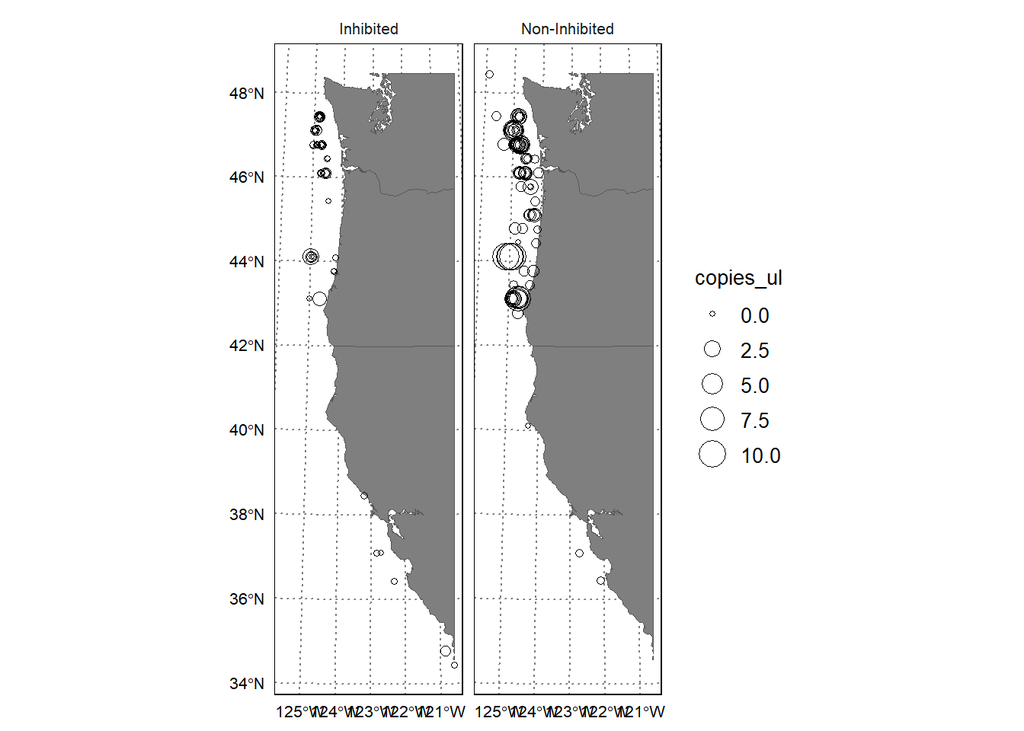

```r
dat.sfc <- dat.samp %>%
  filter(depth_cat==0) %>%
  mutate(is_inhibited=ifelse(inhibition_rate>0.5,"Inhibited","Non-Inhibited")) %>%
  filter(!is.na(utm.lat.m))

dat.sfc.sf <- dat.sfc %>%
  mutate(copies_ul=ifelse(copies_ul>10,10,copies_ul)) %>%
  st_as_sf(coords=c("utm.lon.m","utm.lat.m"),crs=crs(dat_raster))

dat.sfc.p <- ggplot()+
  geom_sf(data=coast,fill='gray50')+
  geom_sf(data=dat.sfc.sf,aes(size=copies_ul),shape=1)+
  facet_wrap(~is_inhibited)+
  scale_color_viridis()
dat.sfc.p
```

50m

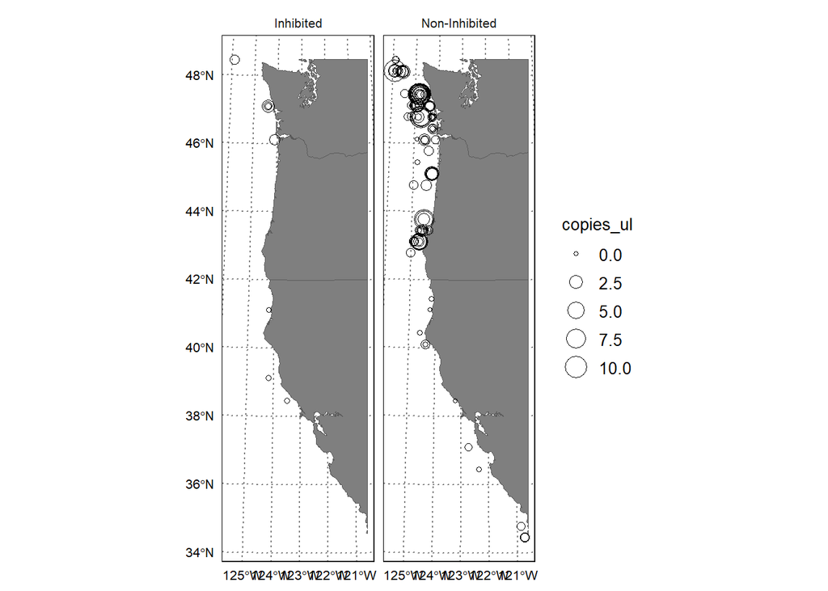

```r
dat.50 <- dat.samp %>%
  filter(depth_cat==50) %>%
  mutate(is_inhibited=ifelse(inhibition_rate>0.5,"Inhibited","Non-Inhibited")) %>%
  filter(!is.na(utm.lat.m))

dat.50.sf <- dat.50 %>%
  mutate(copies_ul=ifelse(copies_ul>10,10,copies_ul)) %>%
  st_as_sf(coords=c("utm.lon.m","utm.lat.m"),crs=crs(dat_raster))

dat.50.p <- ggplot()+
  geom_sf(data=coast,fill='gray50')+
  geom_sf(data=dat.50.sf,aes(size=copies_ul),shape=1)+
  facet_wrap(~is_inhibited)+
  scale_color_viridis()
dat.50.p
```

150m

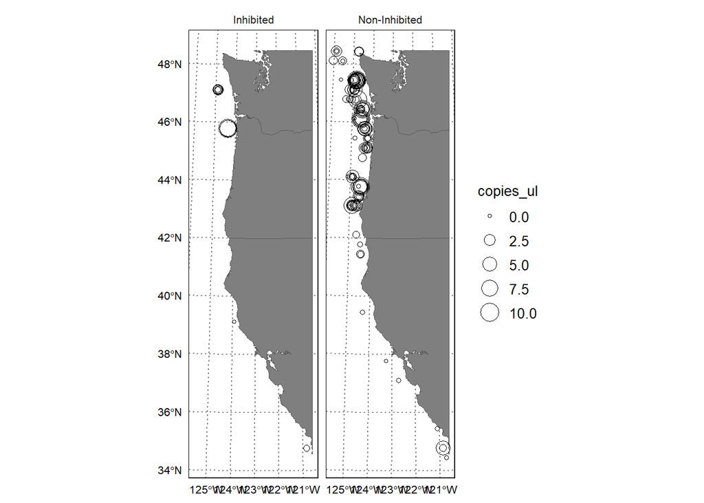

```r
dat.150 <- dat.samp %>%
  filter(depth_cat==150) %>%
  mutate(is_inhibited=ifelse(inhibition_rate>0.5,"Inhibited","Non-Inhibited")) %>%
  filter(!is.na(utm.lat.m))

dat.150.sf <- dat.150 %>%
  mutate(copies_ul=ifelse(copies_ul>10,10,copies_ul)) %>%
  st_as_sf(coords=c("utm.lon.m","utm.lat.m"),crs=crs(dat_raster))

dat.150.p <- ggplot()+
  geom_sf(data=coast,fill='gray50')+
  geom_sf(data=dat.150.sf,aes(size=copies_ul),shape=1)+
  facet_wrap(~is_inhibited)+
  scale_color_viridis()
dat.150.p
```

200m

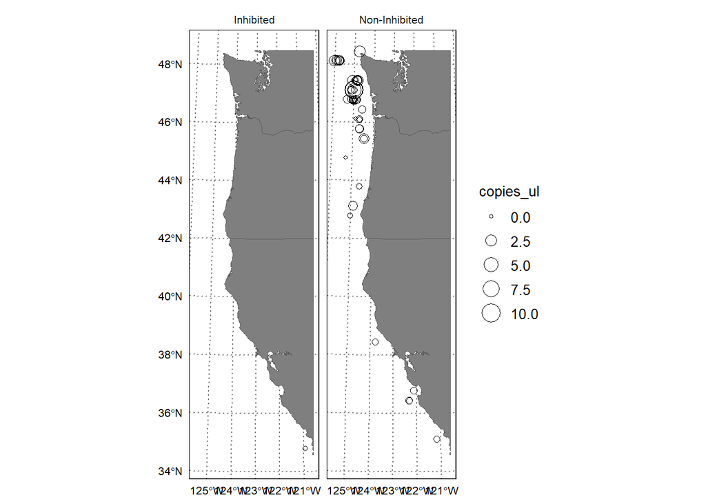

```r
dat.200 <- dat.samp %>%
  filter(depth_cat==200) %>%
  mutate(is_inhibited=ifelse(inhibition_rate>0.5,"Inhibited","Non-Inhibited")) %>%
  filter(!is.na(utm.lat.m))

dat.200.sf <- dat.200 %>%
  mutate(copies_ul=ifelse(copies_ul>10,10,copies_ul)) %>%
  st_as_sf(coords=c("utm.lon.m","utm.lat.m"),crs=crs(dat_raster))

dat.200.p <- ggplot()+
  geom_sf(data=coast,fill='gray50')+
  geom_sf(data=dat.200.sf,aes(size=copies_ul),shape=1)+
  facet_wrap(~is_inhibited)+
  scale_color_viridis()
dat.200.p
```

300m

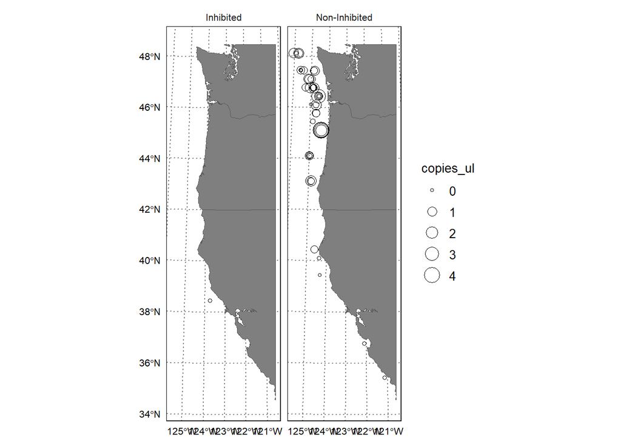

```r
dat.300 <- dat.samp %>%
  filter(depth_cat==300) %>%
  mutate(is_inhibited=ifelse(inhibition_rate>0.5,"Inhibited","Non-Inhibited")) %>%
  filter(!is.na(utm.lat.m))

dat.300.sf <- dat.300 %>%
  mutate(copies_ul=ifelse(copies_ul>10,10,copies_ul)) %>%
  st_as_sf(coords=c("utm.lon.m","utm.lat.m"),crs=crs(dat_raster))

dat.300.p <- ggplot()+
  geom_sf(data=coast,fill='gray50')+
  geom_sf(data=dat.300.sf,aes(size=copies_ul),shape=1)+
  facet_wrap(~is_inhibited)+
  scale_color_viridis()
dat.300.p
```

500m

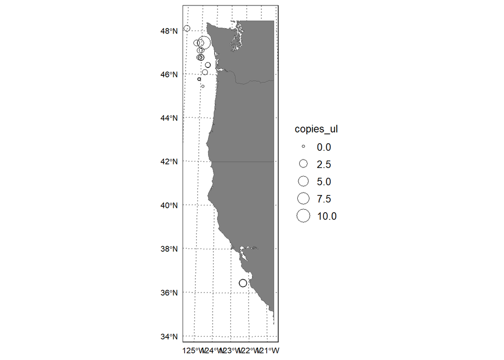

```r
dat.500 <- dat.samp %>%
  filter(depth_cat==500) %>%
  mutate(is_inhibited=ifelse(inhibition_rate>0.5,"Inhibited","Non-Inhibited")) %>%
  filter(!is.na(utm.lat.m))

dat.500.sf <- dat.500 %>%
  mutate(copies_ul=ifelse(copies_ul>10,10,copies_ul)) %>%
  st_as_sf(coords=c("utm.lon.m","utm.lat.m"),crs=crs(dat_raster))

dat.500.p <- ggplot()+
  geom_sf(data=coast,fill='gray50')+
  geom_sf(data=dat.500.sf,aes(size=copies_ul),shape=1)+
  # none inhibited
  # facet_wrap(~is_inhibited)+
  scale_color_viridis()
dat.500.p
```

## Cross-sections by Transect

Transect reference

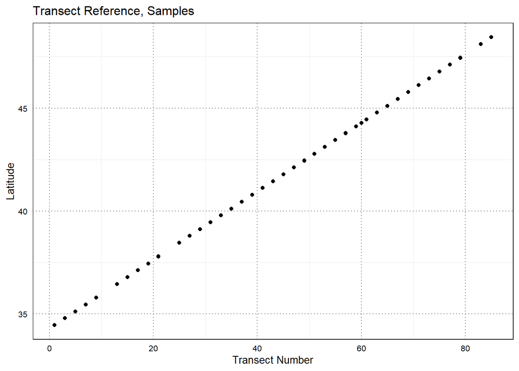

```r
transects.ref.samp <- dat.samp %>%
  ggplot(aes(transect,lat))+
  geom_point()+
  labs(x="Transect Number",y="Latitude",title="Transect Reference, Samples")
transects.ref.samp
```

```r
# transects.ref.acoustic <- dat.acoustic %>%
#   ggplot(aes(transect,lat))+
#   geom_point()+
#   labs(x="Transect Number",y="Latitude",title="Transect Reference, Acoustic")
# transects.ref.acoustic
```

```r
plot_transect <- function(df,transect_id){
  dfsub <- df %>%
    filter(transect==transect_id) %>%
    mutate(transect_dist_km=as.numeric(transect_dist_m/1000))
  outp <- dfsub %>%
    ggplot(aes(transect_dist_km,depth_cat,size=log(copies_ul)))+
    geom_point(shape=1)+
    scale_y_reverse()+
    scale_x_reverse()+
    # scale_size_continuous(limits=c(-6,8),breaks=seq(-6,9,by=5))+
    labs(x="Distance Along Transect",y="Depth",size="Log Copies (ul)",title=paste0("Transect ",transect_id))
  outp
}
```

Plot the transect cross-sections

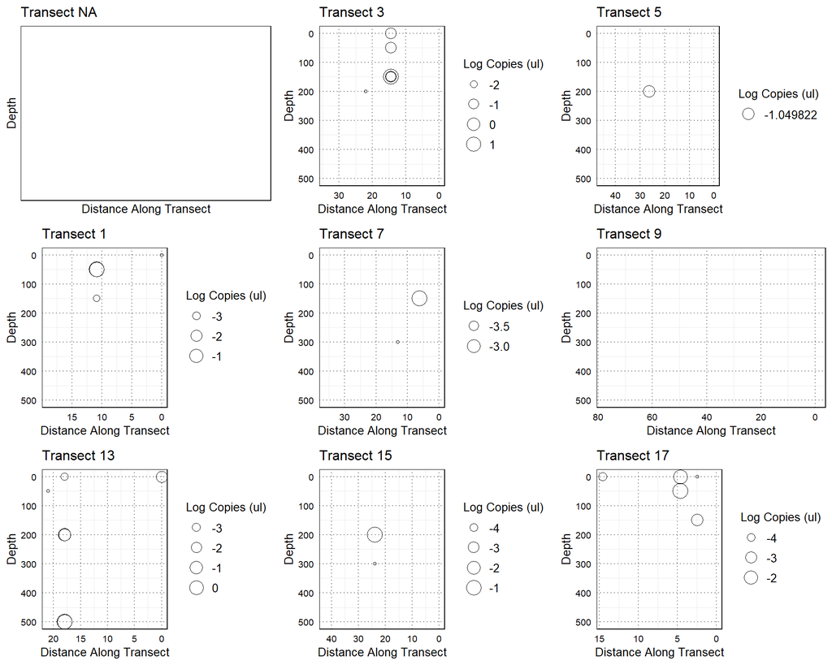

```r
transect.cross.sections <- purrr::map(unique(dat.samp$transect),plot_transect,df=dat.samp)

cowplot::plot_grid(plotlist=transect.cross.sections[1:9],nrow=3)
```

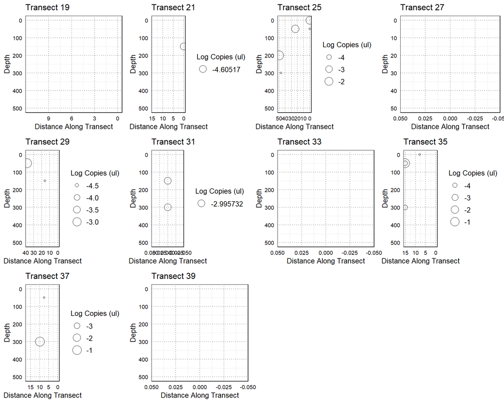

```r
cowplot::plot_grid(plotlist=transect.cross.sections[10:19],nrow=3)
```

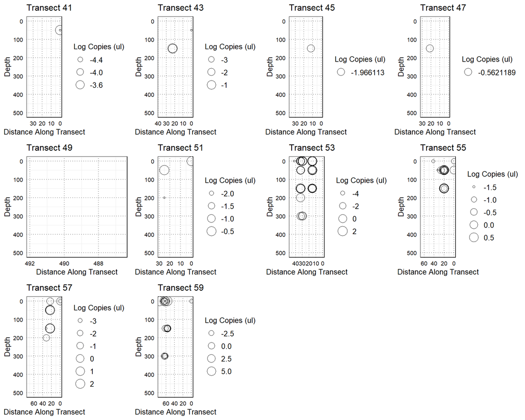

```r
cowplot::plot_grid(plotlist=transect.cross.sections[20:29],nrow=3)
```

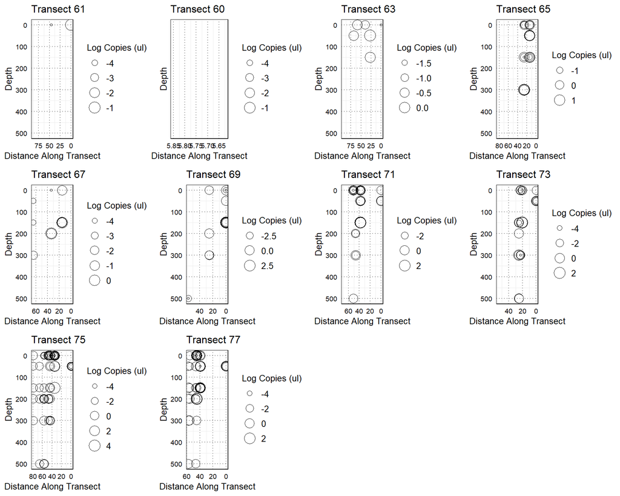

```r
cowplot::plot_grid(plotlist=transect.cross.sections[30:39],nrow=3)
```

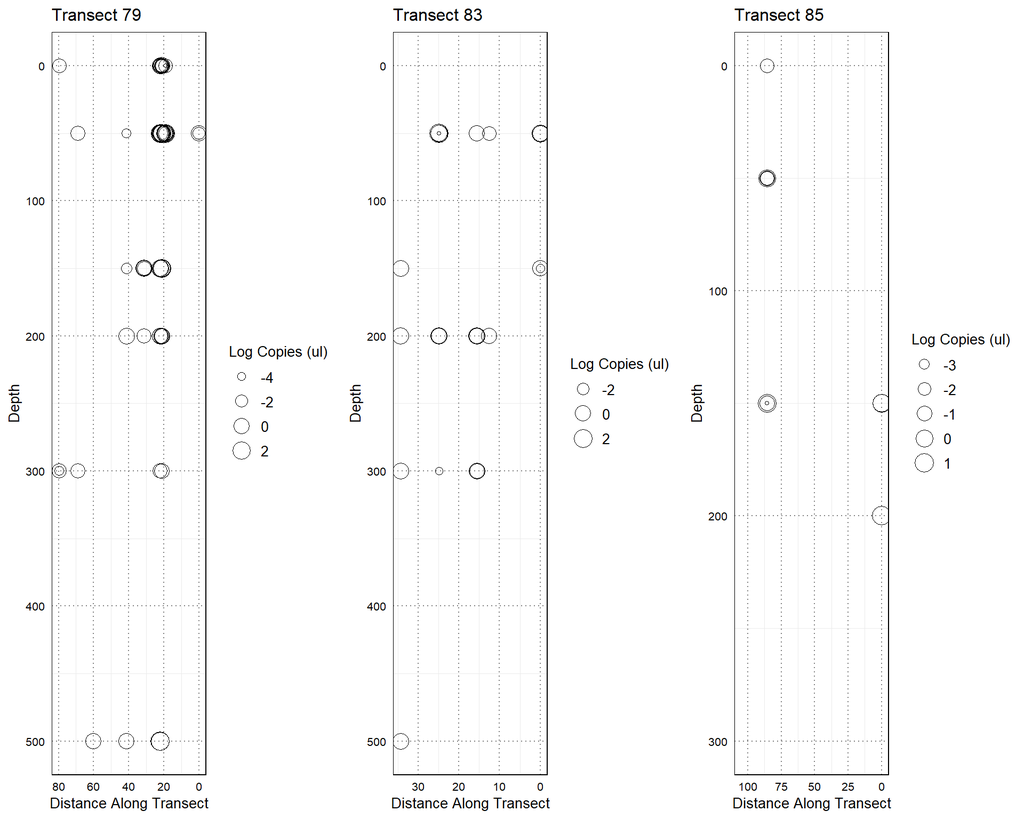

```r
cowplot::plot_grid(plotlist=transect.cross.sections[40:42],nrow=1)
```

## Standards

Plot standard curves

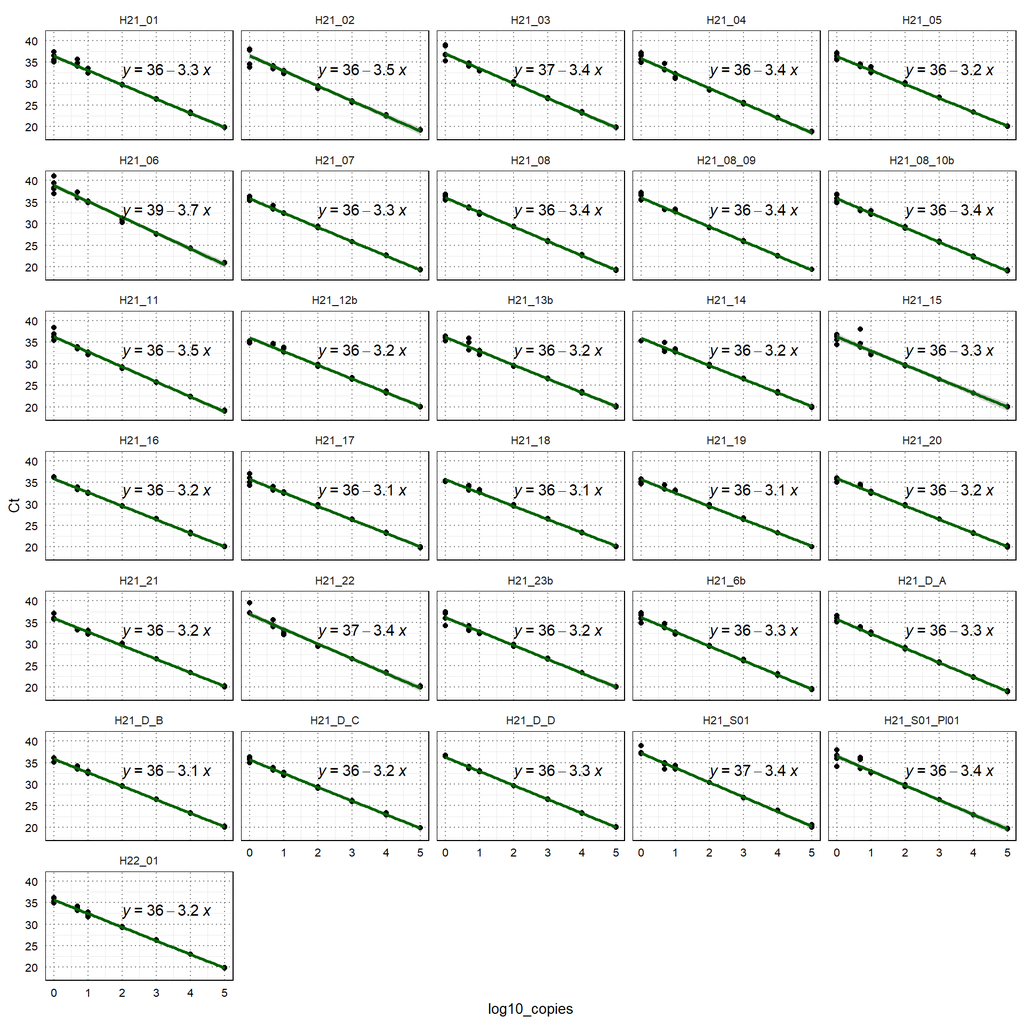

```r
# stand.curve.plots <- purrr::map(unique(dat.stand$qPCR),function(s){
#   dat.stand %>%
#     filter(qPCR==s,Ct!=-99) %>%
#     ggplot(aes(log10_copies,Ct))+
#     geom_point()+
#     geom_smooth(method='lm',color='darkgreen')+
#     labs(title=paste0("qPCR: ",s))+
#     stat_regline_equation(label.x = 2, label.y = 33)
#
# })
# stand.curve.plots[[1]]

stand.curve.plots <- dat.stand %>%
  filter(Ct!=-99) %>%
  ggplot(aes(log10_copies,Ct))+
  geom_point()+
  geom_smooth(method='lm',color='darkgreen')+
  facet_wrap(~qPCR,nrow=7,ncol=5)+
  stat_regline_equation(label.x = 2, label.y = 33)
stand.curve.plots
```

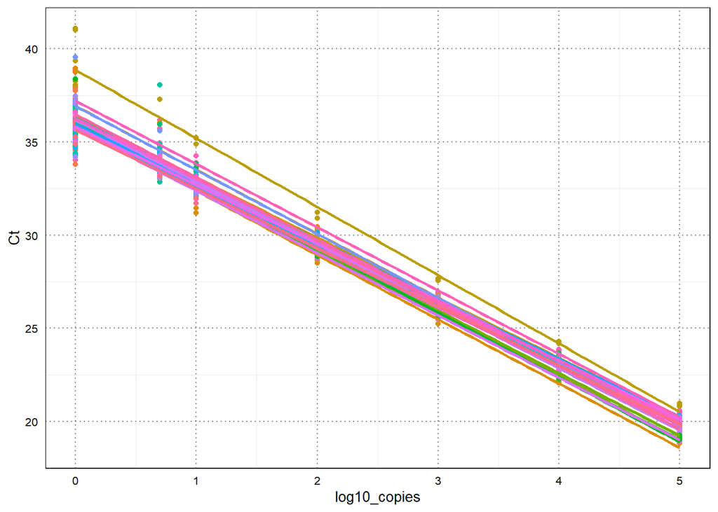

```r
stand.curves.all <- dat.stand %>%
  filter(Ct!=-99) %>%
  ggplot(aes(log10_copies,Ct,color=qPCR))+
  geom_point()+
  guides(color='none')+
  geom_smooth(method='lm',se=F)
stand.curves.all
```

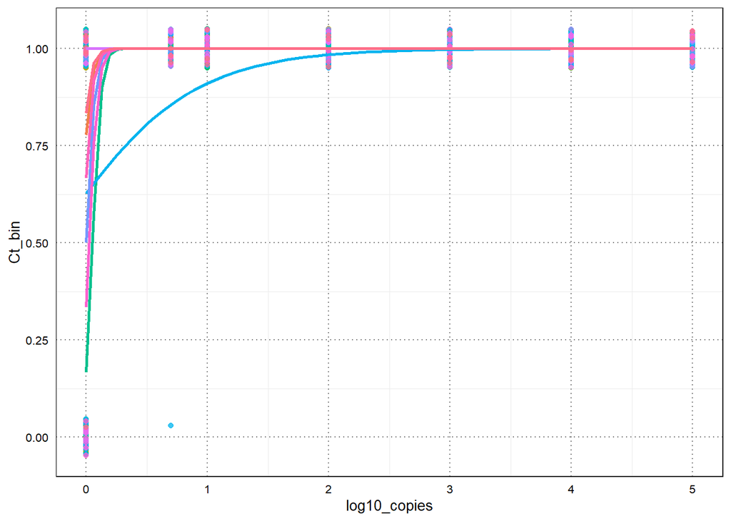

```r
# amplification success?
qpcr_success <- dat.stand %>%
  ggplot(aes(x=log10_copies ,y=Ct_bin,color=qPCR))+
  geom_jitter(alpha=0.75,width=0,height=0.05)+
  guides(color='none')+
  geom_smooth(method = "glm",
    method.args = list(family = "binomial"),
    se = FALSE)
qpcr_success
```